# Project 1: Hurricanes Data

Cynthia Li 3034939311

10/8/2021

### Learning Objectives

> - Perform an exploratory analysis of tropical storms in the North Atlantic from years 1970 to 2019

## A.1) Recommended R Packages

```r
library(tidyverse)
library(lubridate)
library(spData)
library(gganimate)
library(gganimate)
library(png)
library(gifski)
```

## A.2) Importing Data in R

```r
col_names <- c(
  "SID",
  "SEASON",
  "NUMBER",
  "BASIN",
  "SUBBASIN",
  "NAME",
  "ISO_TIME",
  "NATURE",
  "LAT",
  "LON",
  "WMO_WIND",
  "WMO_PRES",
  "WMO_AGENCY",
  "TRACK_TYPE",
  "DIST2LAND",
  "LANDFALL"
)

col_types <- c(
  "character",
  "integer",
  "integer",
  "character",
  "character",
  "character",
  "character",
  "character",
  "double",
  "real",
  "integer",
  "integer",
  "character",
  "character",
  "integer",
  "integer"
)

dat <- read.csv(
  file = "ibtracs.NA.list.v04r00.csv",
  colClasses = c(col_types, rep("NULL", 147)),
  stringsAsFactors = FALSE,
  skip = 77876,
  na.strings = c("MM", " ", "NR")
)

colnames(dat) <- col_names
```

## A.3) Adding a MONTH column

```r
# Adding month
dat$ISO_TIME = as.POSIXct(dat$ISO_TIME)
dat$MONTH <- lubridate::month(dat$ISO_TIME)
# Display structure of the data
str(dat, vec.len = 1)
```

```
## 'data.frame':    46083 obs. of  17 variables:
##  $ SID       : chr  "1970138N12281" ...
##  $ SEASON    : int  1970 1970 ...
##  $ NUMBER    : int  43 43 ...
##  $ BASIN     : chr  "NA" ...
##  $ SUBBASIN  : chr  "CS" ...
##  $ NAME      : chr  "ALMA" ...
##  $ ISO_TIME  : POSIXct, format: "1970-05-17 18:00:00" ...
##  $ NATURE    : chr  "TS" ...
##  $ LAT       : num  11.5 ...
##  $ LON       : num  -79 ...
##  $ WMO_WIND  : int  25 NA ...
##  $ WMO_PRES  : int  NA NA ...
##  $ WMO_AGENCY: chr  "hurdat_atl" ...
##  $ TRACK_TYPE: chr  "main" ...
##  $ DIST2LAND : int  224 235 ...
##  $ LANDFALL  : int  224 235 ...
##  $ MONTH     : num  5 5 ...
```

## B) Univariate Exploratory Data Analysis

## C.1) Are hurricanes becoming more frequent?

I would like to get a table in which the first represents the year/season and the second column represents the counts of hurricanes in that year. Then I want to draw a line chart to visualize the change from 1970 to 2019.

```r
uniq_storm <- distinct(dat, SID, SEASON)
uniq_storm_cnts_per_season <- count(uniq_storm, SEASON)
# Remove the last two rows that represent 2020 and 2021 seasons from the table
uniq_storm_cnts_1970_2019 <- head(uniq_storm_cnts_per_season, -2)
# Display the table
uniq_storm_cnts_1970_2019
```

```
##    SEASON  n
## 1    1970 19
## 2    1971 22
## 3    1972 19
## 4    1973 17
## 5    1974 20
## 6    1975 23
## 7    1976 21
## 8    1977 15
## 9    1978 24
## 10   1979 20
## 11   1980 18
## 12   1981 22
## 13   1982  8
## 14   1983  6
```

[output cut: 36 more lines]

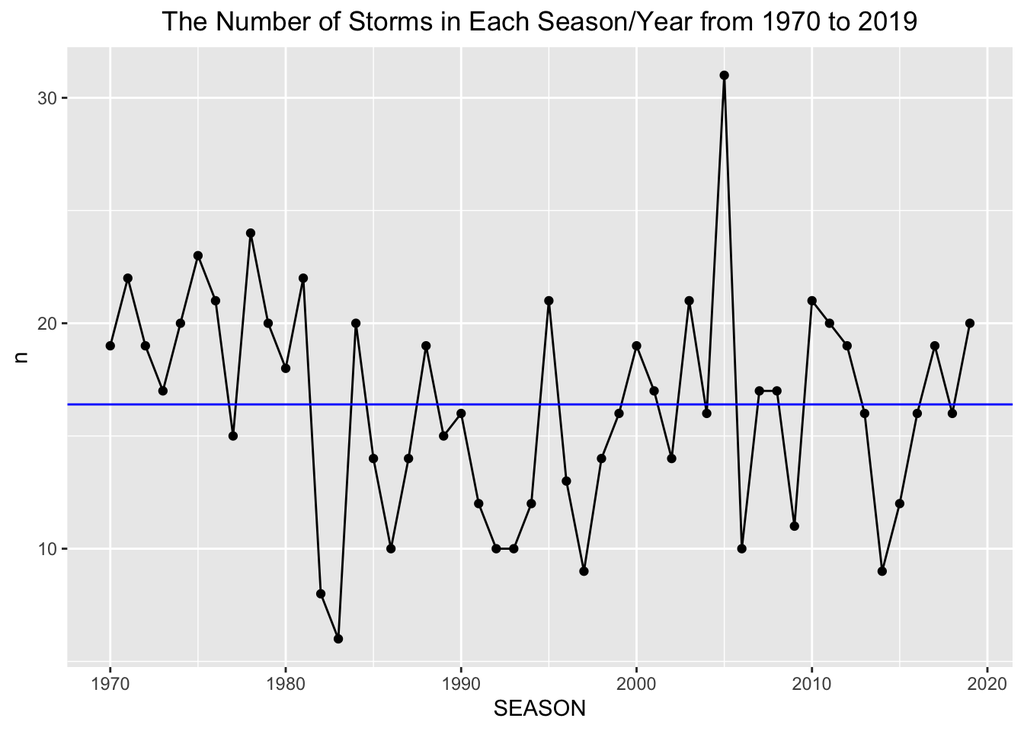

```r
# To show the tendency, I choose to draw a line chart
theme_update(plot.title = element_text(hjust = 0.5))
ggplot(data = uniq_storm_cnts_1970_2019) +
  geom_point(aes(x = SEASON, y = n)) +
  geom_line(aes(x = SEASON, y = n)) +
  geom_hline(aes(yintercept = mean(n)), color = "blue") +
  ggtitle("The Number of Storms in Each Season/Year from 1970 to 2019")
```

As we can see from the line chart generated by the table above, the data points which represent the number of hurricanes in a season deviate from the average horizontal line. If the general tendency of the frequency of storms each year is increasing, we would expect the data points in recent years, on the right side of the graph, are above the average horizontal line, while the data points in the left part of the graph are below the average horizontal line. There is a data point that deviates from other points: the maximum counts of hurricanes in a year is 31 in 2005. However, the general tendency reflected by the line chart is still horizontal. Therefore, hurricanes(“storms” is a more precise term here) are not becoming more frequent year over year from 1970 to 2019.

## C.2) Are hurricanes getting stronger?

```r
uniq_rows <- distinct(dat, SID, .keep_all = TRUE)
uniq_rows_1970_2019 <- filter(uniq_rows, SEASON <= 2019)
avg_wind_speed_and_pres_per_year <- summarise(
  group_by(uniq_rows_1970_2019, SEASON),
  avg_wind_speed = mean(WMO_WIND, na.rm = TRUE),
  avg_wind_pressure = mean(WMO_PRES, na.rm = TRUE)
)
avg_wind_speed_and_pres_per_year
```

```
## # A tibble: 50 × 3
##    SEASON avg_wind_speed avg_wind_pressure
##     <int>          <dbl>             <dbl>
##  1   1970           23.4             1010.
##  2   1971           22.7             1009.
##  3   1972           22.8             1010.
##  4   1973           24.4             1009.
##  5   1974           25.3             1010.
##  6   1975           23.3             1008.
##  7   1976           21.0             1011.
##  8   1977           21.3             1011.
##  9   1978           22.7             1010
## 10   1979           22               1009.
## # … with 40 more rows
```

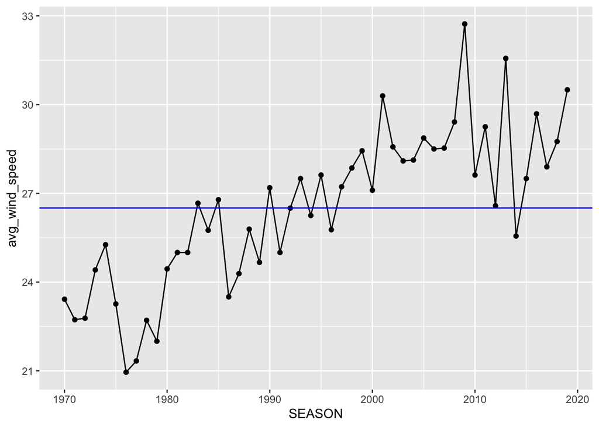

```r
# Draw the line chart for the avg wind speed per year
theme_update(plot.title = element_text(hjust = 0.5))
ggplot(data = avg_wind_speed_and_pres_per_year) +
  geom_point(aes(x = SEASON, y = avg_wind_speed)) +
  geom_line(aes(x = SEASON, y = avg_wind_speed)) +
  geom_hline(aes(yintercept = mean(avg_wind_speed)), color = "blue")
```

```r
  ggtitle("The Average Wind Speed of Hurricanes in Each Season/Year from 1970 to 2019")
```

```
## $title
## [1] "The Average Wind Speed of Hurricanes in Each Season/Year from 1970 to 2019"
##
## attr(,"class")
## [1] "labels"
```

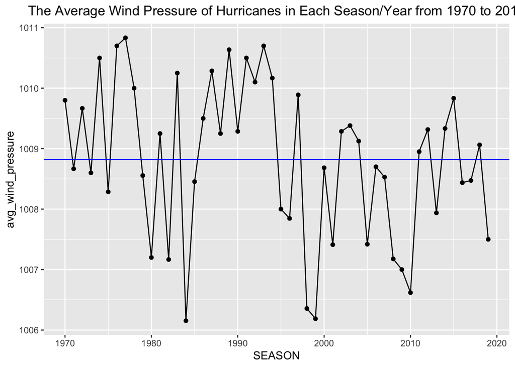

```r
# Draw the line chart for the avg wind pressure per year
theme_update(plot.title = element_text(hjust = 0.5))
ggplot(data = avg_wind_speed_and_pres_per_year) +
  geom_point(aes(x = SEASON, y = avg_wind_pressure)) +
  geom_line(aes(x = SEASON, y = avg_wind_pressure)) +
  geom_hline(aes(yintercept = mean(avg_wind_pressure)), color = "blue") +
  ggtitle("The Average Wind Pressure of Hurricanes in Each Season/Year from 1970 to 2019")
```

In the first line chart “The Average Wind Speed of Hurricanes in Each Season/Year from 1970 to 2019”, we can see the tendency that the average weed speed of each year is increasing from 1970 to 2019. In the second line chart “The Average Wind Pressure of Hurricanes in Each Season/Year from 1970 to 2019”, we can see the average wind pressure of hurricanes of each year deviates from the average horizontal line from 1970 to 2020, indicating no tendency of decreasing or increasing. Observing the increasing tendency in wind speed, I conclude that hurricanes are getting stronger year over year from 1970 to 2019.

## C.3) 2019 Atlantic Hurricane Season

Claim a) The 2019 Atlantic hurricane season had 20 tropical cyclones, of which 18 were names storms.

```r
# First, get a table recording all unique storms in 2019
uniq_storms_2019 <- distinct(filter(dat, SEASON == 2019), SID, .keep_all = TRUE)
uniq_storms_2019
```

```
##              SID SEASON NUMBER BASIN SUBBASIN      NAME            ISO_TIME
## 1  2019141N28291   2019     25    NA       NA    ANDREA 2019-05-20 18:00:00
## 2  2019192N29274   2019     33    NA       GM     BARRY 2019-07-10 12:00:00
## 3  2019204N25283   2019     37    NA       NA NOT_NAMED 2019-07-22 12:00:00
## 4  2019233N40300   2019     50    NA       NA   CHANTAL 2019-08-20 18:00:00
## 5  2019236N10314   2019     52    NA       NA    DORIAN 2019-08-24 06:00:00
## 6  2019239N32287   2019     54    NA       NA      ERIN 2019-08-26 12:00:00
## 7  2019246N16330   2019     60    NA       NA GABRIELLE 2019-09-03 00:00:00
## 8  2019246N24266   2019     61    NA       GM   FERNAND 2019-09-03 06:00:00
## 9  2019256N23286   2019     65    NA       NA  HUMBERTO 2019-09-12 12:00:00
## 10 2019260N13317   2019     68    NA       NA     JERRY 2019-09-17 00:00:00
## 11 2019261N28264   2019     70    NA       GM    IMELDA 2019-09-17 12:00:00
## 12 2019265N12301   2019     72    NA       NA     KAREN 2019-09-22 00:00:00
## 13 2019266N11341   2019     73    NA       NA   LORENZO 2019-09-22 18:00:00
## 14 2019282N35286   2019     78    NA       NA   MELISSA 2019-10-08 18:00:00
```

[output cut: 48 more lines]

```r
# Count the number of rows in this table, so we can know how many storms a.k.a tropical cyclones are there in 2019 Atlantic hurricane season.
nrow(uniq_storms_2019)
```

```
## [1] 20
```

```r
# Among these 20 tropical cyclones in 2019, filter out tropical cyclones that are named.
named_storms_2019 <- filter(uniq_storms_2019, NAME != "NOT_NAMED")
named_storms_2019
```

```
##              SID SEASON NUMBER BASIN SUBBASIN      NAME            ISO_TIME
## 1  2019141N28291   2019     25    NA       NA    ANDREA 2019-05-20 18:00:00
## 2  2019192N29274   2019     33    NA       GM     BARRY 2019-07-10 12:00:00
## 3  2019233N40300   2019     50    NA       NA   CHANTAL 2019-08-20 18:00:00
## 4  2019236N10314   2019     52    NA       NA    DORIAN 2019-08-24 06:00:00
## 5  2019239N32287   2019     54    NA       NA      ERIN 2019-08-26 12:00:00
## 6  2019246N16330   2019     60    NA       NA GABRIELLE 2019-09-03 00:00:00
## 7  2019246N24266   2019     61    NA       GM   FERNAND 2019-09-03 06:00:00
## 8  2019256N23286   2019     65    NA       NA  HUMBERTO 2019-09-12 12:00:00
## 9  2019260N13317   2019     68    NA       NA     JERRY 2019-09-17 00:00:00
## 10 2019261N28264   2019     70    NA       GM    IMELDA 2019-09-17 12:00:00
## 11 2019265N12301   2019     72    NA       NA     KAREN 2019-09-22 00:00:00
## 12 2019266N11341   2019     73    NA       NA   LORENZO 2019-09-22 18:00:00
## 13 2019282N35286   2019     78    NA       NA   MELISSA 2019-10-08 18:00:00
## 14 2019291N22264   2019     85    NA       GM    NESTOR 2019-10-17 12:00:00
```

[output cut: 42 more lines]

```r
# Finally, we can find how many of them are named.
nrow(named_storms_2019)
```

```
## [1] 18
```

After using filter() and nrow() functions to select distinct storms a.k.a tropical cyclones in 2019 and get the number of rows, we can see that the 2019 Atlantic hurricane season had 20 tropical cyclones, of which 18 were names storms. Claim a) is true.

Claim b) The 2019 Atlantic hurricane season had six named storms that achieved hurricane status.

```r
named_storms_2019 <- filter(dat, SEASON == 2019, NAME != "NOT_NAMED")
# Want to find the max sustained wind speed for each storms with unique SID in 2019
max_wind_speed_2019 <- summarise(
  group_by(named_storms_2019, SID),
  max_wind_speed = max(WMO_WIND, na.rm = TRUE),
)
# Display the table to show the max sustained wind speed for each unique storm in 2019
max_wind_speed_2019
```

```
## # A tibble: 18 × 2
##    SID           max_wind_speed
##    <chr>                  <int>
##  1 2019141N28291             35
##  2 2019192N29274             65
##  3 2019233N40300             35
##  4 2019236N10314            160
##  5 2019239N32287             35
##  6 2019246N16330             55
##  7 2019246N24266             45
##  8 2019256N23286            110
##  9 2019260N13317             90
## 10 2019261N28264             40
## 11 2019265N12301             40
## 12 2019266N11341            140
## 13 2019282N35286             55
## 14 2019291N22264             50
## 15 2019297N40322             70
## 16 2019299N25265             45
## 17 2019300N41309             70
## 18 2019323N19302             60
```

```r
# Filter out the table which contains storms with max sustained wind speed greater than or equal to 64 knots
filter(max_wind_speed_2019, max_wind_speed >= 64)
```

```
## # A tibble: 7 × 2
##   SID           max_wind_speed
##   <chr>                  <int>
## 1 2019192N29274             65
## 2 2019236N10314            160
## 3 2019256N23286            110
## 4 2019260N13317             90
## 5 2019266N11341            140
## 6 2019297N40322             70
## 7 2019300N41309             70
```

There are seven storms that achieved hurricane status, so claim b) is false.

Claim c) The 2019 Atlantic hurricane season had three named storms that intensified into major hurricanes, all of which became Category 5 hurricanes.

```r
# Major hurricanes: max sustained wind speed >= 111 mph / 96.4564 knots
filter(max_wind_speed_2019, max_wind_speed >= 96.4564)
```

```
## # A tibble: 3 × 2
##   SID           max_wind_speed
##   <chr>                  <int>
## 1 2019236N10314            160
## 2 2019256N23286            110
## 3 2019266N11341            140
```

```r
# Category 5: max sustained wind speed >= 157 mph / 136.429 knots
filter(max_wind_speed_2019, max_wind_speed >= 136.429)
```

```
## # A tibble: 2 × 2
##   SID           max_wind_speed
##   <chr>                  <int>
## 1 2019236N10314            160
## 2 2019266N11341            140
```

The 2019 Atlantic hurricane season had three named storms that intensified into major hurricanes, two of which became Category 5 hurricanes. Therefore, Claim c) is false.

Claim d) There was one storm in 2019 that formed outside the official hurricane season (recall that the official season goes from June 1 to November 30).

```r
# First, filter the table with storms in Month outside 6:11 in 2019
f1 <- filter(dat, SEASON == 2019, !MONTH %in% 6:11)
f1
```

```
##              SID SEASON NUMBER BASIN SUBBASIN   NAME            ISO_TIME NATURE
## 1  2019141N28291   2019     25    NA       NA ANDREA 2019-05-20 18:00:00     SS
## 2  2019141N28291   2019     25    NA       NA ANDREA 2019-05-20 21:00:00     SS
## 3  2019141N28291   2019     25    NA       NA ANDREA 2019-05-21 00:00:00     SS
## 4  2019141N28291   2019     25    NA       NA ANDREA 2019-05-21 03:00:00     SS
## 5  2019141N28291   2019     25    NA       NA ANDREA 2019-05-21 06:00:00     SS
## 6  2019141N28291   2019     25    NA       NA ANDREA 2019-05-21 09:00:00     SS
## 7  2019141N28291   2019     25    NA       NA ANDREA 2019-05-21 12:00:00     DS
## 8  2019141N28291   2019     25    NA       NA ANDREA 2019-05-21 15:00:00     DS
## 9  2019141N28291   2019     25    NA       NA ANDREA 2019-05-21 18:00:00     DS
## 10 2019141N28291   2019     25    NA       NA ANDREA 2019-05-21 21:00:00     DS
## 11 2019141N28291   2019     25    NA       NA ANDREA 2019-05-22 00:00:00     DS
## 12 2019141N28291   2019     25    NA       NA ANDREA 2019-05-22 03:00:00     DS
## 13 2019141N28291   2019     25    NA       NA ANDREA 2019-05-22 06:00:00     DS
##        LAT      LON WMO_WIND WMO_PRES WMO_AGENCY TRACK_TYPE DIST2LAND LANDFALL
```

[output cut: 27 more lines]

```r
# Next, extract each unique storm described by the SID
distinct(f1, SID, .keep_all = TRUE)
```

```
##             SID SEASON NUMBER BASIN SUBBASIN   NAME            ISO_TIME NATURE
## 1 2019141N28291   2019     25    NA       NA ANDREA 2019-05-20 18:00:00     SS
##    LAT   LON WMO_WIND WMO_PRES WMO_AGENCY TRACK_TYPE DIST2LAND LANDFALL MONTH
## 1 28.1 -68.6       35     1008 hurdat_atl       main       889      889     5
```

We can see that there is one storm in 2019 that formed outside the official hurricane season. Therefore, claim d) is true.

Claim e) Two storms became Category 5 hurricanes, at least one storm making landfall at Category 5 intensity.

```r
# In c.3) Claim c, we have already create a table which records all named storms in 2019 on line 149
named_storms_2019 <- filter(dat, SEASON == 2019, NAME != "NOT_NAMED")
max_wind_speed_2019 <- summarise(
  group_by(named_storms_2019, SID),
  max_wind_speed = max(WMO_WIND, na.rm = TRUE),
)
max_wind_speed_2019
```

```
## # A tibble: 18 × 2
##    SID           max_wind_speed
##    <chr>                  <int>
##  1 2019141N28291             35
##  2 2019192N29274             65
##  3 2019233N40300             35
##  4 2019236N10314            160
##  5 2019239N32287             35
##  6 2019246N16330             55
##  7 2019246N24266             45
##  8 2019256N23286            110
##  9 2019260N13317             90
## 10 2019261N28264             40
## 11 2019265N12301             40
## 12 2019266N11341            140
## 13 2019282N35286             55
## 14 2019291N22264             50
## 15 2019297N40322             70
## 16 2019299N25265             45
## 17 2019300N41309             70
## 18 2019323N19302             60
```

```r
# On line 167, we have seen that there are two storms that can be characterized by Category 5 hurricanes. So far we know the first part of claim e) is true.
filter(max_wind_speed_2019, max_wind_speed >= 136.429)
```

```
## # A tibble: 2 × 2
##   SID           max_wind_speed
##   <chr>                  <int>
## 1 2019236N10314            160
## 2 2019266N11341            140
```

```r
# To know whether the second part of claim e) is correct, we want to check whether one of these two Category 5 hurricanes has made a landfall i.e. landfall == 0
two_category_5_hurricanes <- filter(dat, SID == "2019236N10314" | SID == "2019266N11341")
f2 <- filter(two_category_5_hurricanes, LANDFALL == 0)
f2
```

```
##             SID SEASON NUMBER BASIN SUBBASIN    NAME            ISO_TIME NATURE
## 1 2019236N10314   2019     52    NA       NA  DORIAN 2019-09-07 21:00:00     DS
## 2 2019236N10314   2019     52    NA       NA  DORIAN 2019-09-08 00:00:00     DS
## 3 2019236N10314   2019     52    NA       NA  DORIAN 2019-09-08 03:00:00     DS
## 4 2019236N10314   2019     52    NA       NA  DORIAN 2019-09-08 18:00:00     ET
## 5 2019236N10314   2019     52    NA       NA  DORIAN 2019-09-08 21:00:00     ET
## 6 2019266N11341   2019     73    NA       NA LORENZO 2019-10-04 03:00:00     ET
##       LAT       LON WMO_WIND WMO_PRES WMO_AGENCY TRACK_TYPE DIST2LAND LANDFALL
## 1 43.9692 -63.65140       NA       NA       <NA>       main        45        0
## 2 45.2000 -62.90000       80      956 hurdat_atl       main         0        0
## 3 46.4433 -62.37870       NA       NA       <NA>       main         0        0
## 4 50.8000 -57.90000       60      966 hurdat_atl       main        36        0
## 5 51.2542 -56.38750       NA       NA       <NA>       main         0        0
## 6 54.9584  -9.28996       NA       NA       <NA>       main        46        0
##   MONTH
## 1     9
## 2     9
## 3     9
## 4     9
## 5     9
## 6    10
```

```r
# Find how many of these two Category 5 are in the table above
distinct(f2, SID)
```

```
##             SID
## 1 2019236N10314
## 2 2019266N11341
```

## C.4) Animated Map

First, I plot the locations of the storms with their longitude and latitude on a map. source: http://www.gastonsanchez.com/intro2cwd/eda-maps.html

```r
library(dplyr) # for syntactic manipulation of tables
library(ggplot2) # for making graphs based on tabular data
library(maps) # for drawing basic geographical maps
library(rnaturalearth) # world map data from Natural Earth
```

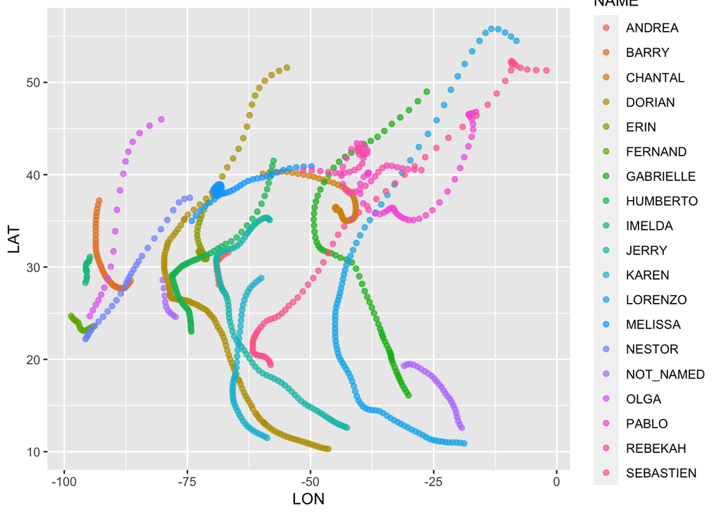

```r
storms2019 <- filter(dat, SEASON == 2019)
ggplot(data = storms2019, aes(x = LON, y = LAT, color = NAME)) +
  geom_point(alpha = 0.7)
```

```r
# Convert the map-object into a data frame, so we can use the map data objects from "map" with "ggplot2".
world_map <- map_data("world")
head(world_map)
```

```
##        long      lat group order region subregion
## 1 -69.89912 12.45200     1     1  Aruba      <NA>
## 2 -69.89571 12.42300     1     2  Aruba      <NA>
## 3 -69.94219 12.43853     1     3  Aruba      <NA>
## 4 -70.00415 12.50049     1     4  Aruba      <NA>
## 5 -70.06612 12.54697     1     5  Aruba      <NA>
## 6 -70.05088 12.59707     1     6  Aruba      <NA>
```

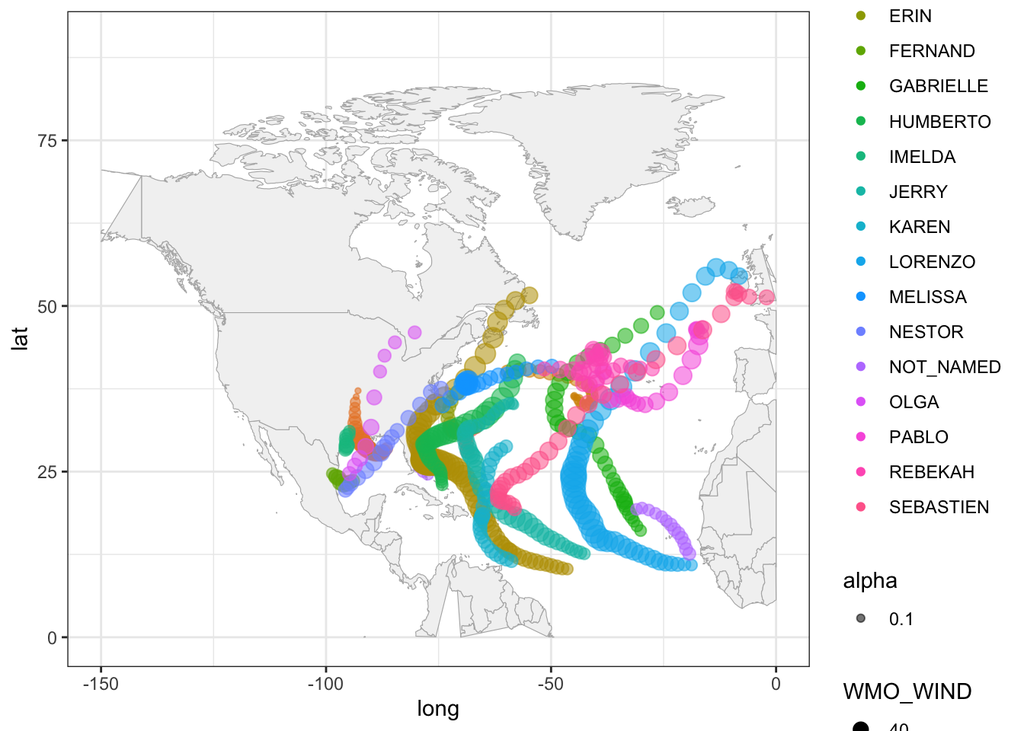

```r
gg_world <- ggplot() +
  geom_polygon(data = world_map,
               aes(x = long, y = lat, group = group),
               fill = "gray95",
               colour = "gray70",
               size = 0.2) +
  theme_bw()

# Plot the storms on the gg_world world map

map <- gg_world +
  geom_point(data = storms2019, aes(x = LON, y = LAT, color = NAME, size = WMO_WIND, alpha = 0.1)) +
  xlim(c(-150, 0)) +
  ylim(c(0, 90))
map
```

Now, draw the animated tracking map.

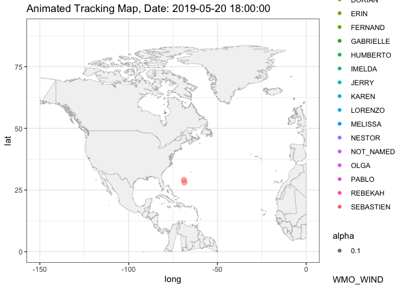

```r
ani <- map +
  labs(title = "Animated Tracking Map, Date: {frame_time}") +
  transition_time(ISO_TIME) +
  shadow_wake(wake_length = 0.1, alpha = FALSE) +
  exit_disappear(early = TRUE)

animate(ani, nframes = 300, fps=7)
```